# Midterm

Yiping Li 2022-12-05

```r
library(readxl)
library(plyr)
library(dplyr)
library(skimr)
library(ggplot2)
```

Introduction: In the United States, more than half of the total dietary energy consumption has been composed by ultra-processed foods (UPFs). Most UPFs are calorie-dense and high in sugar, salt, and unhealthy fats, while low in protein, vitamins, and minerals. Studies have demonstrated that the increased consumption of UPFs could result in a poor nutritional quality of the overall diet and high chances of developing chronic diseases. Therefore, the aim of the study focuses on exploring the association between UPF consumption and type 2 diabetes (T2DM) and obesity among youth.

Method: The data used were obtained from the baseline visit (between 2014 and 2018) of the Children’s Health Study, which contained 158 participants aging from 17 to 22 years old. The 24-hour recall was used to obtain the food items that participants consumed and to further calculate the UPF consumption percentage (UPF%), which equaled to the UPF consumption amount in grams divided by total food consumption amount in grams. A total of 155 participants had appropriate UPF% were included in the study. After exclude participants who did not have T2DM related variables and implausible blood glucose levels, a total of 153 participants were being studied. Demographic variables, BMI, UPF%, and T2DM related variables (fasting glucose, blood glucose after 120 minutes, and HbA1c) were included in this particular study.

*Ultra-Processed Food Definition and Classification Ultra-processed foods are defined as food items that go through multiple manipulated process before people purchase or eat them. A total of 1167 food items (including ingredients) were collected at baseline visit and a total of 807 food items were collected were collected at follow-up visit using 24-hour dietary recalls (24HRs). Two reviewers conducted following two processes independently. Firstly, reviewers used NOVA classification to group food items into 4 groups: unprocessed and minimally processed foods, processed culinary ingredients, processed foods, and ultra-processed foods (UPFs). Secondly, reviewers grouped the first 3 groups into non-UPFs group, so only two groups were resulted. After grouping, reviewers had disagreements on food item classification, reviewers share own perspectives to seek an agreement. In general, UPF classification criteria were as following: the major ingredient of a food item; how the food is made in the U.S. normally; the way most people get the food – purchase from a grocery store or homemade.

```r
metaair <- readRDS("/Users/yiping/Desktop/Epi research/OneDrive - University of Southern California/MetaChem/metaair.rds")
UPFMean_grams <- read_excel("/Users/yiping/Desktop/Epi research/USC-Liz/independent research - UPF/UPF% calculation2/UPFgrams_baseline.xlsx")
```

```r
myvars <- c("ID", "cage", "male", "race2", "bmi_avg", "bmiclass", "diabetesbinary", "gluc_fasting", "gluc_120min", "hba1c")
subsetmetachem <- metaair[myvars]
```

```r
vars <- merge(subsetmetachem, UPFMean_grams)
```

```r
vars$UPF_quart <- cut(vars$UPFpercentage_mean,
                          breaks=c(0, 25, 50, 75, 100),
                          labels=c("1", "2", "3", "4"))

vars$UPF_cat <- cut(vars$UPFpercentage_mean,
                             breaks=c(0, 50, 100),
                             labels=c("0", "1"))
```

Appropriate names of variables were given to better view the dataset.

```r
names(vars)[2] <- "Age"
names(vars)[3] <- "Male"
names(vars)[4] <- "Race"
names(vars)[5] <- "BMI_cont"
names(vars)[6] <- "BMI_cat"
names(vars)[7] <-  "Diabetes_cat"
names(vars)[8] <- "Gluc_Fasting"
names(vars)[9] <- "Gluc_120min"
names(vars)[10] <- "HbA1C"
```

Participants with missing values in T2DM or fasting glucose or blood glucose after 120 minutes were excluded. Participants with implausible fasting glucose of greater than 200 mg/dL and glucose after 120 minutes of greater than 400 mg/dL were also excluded.

```r
vars <- vars %>%
  filter(!is.na(Diabetes_cat)) %>%
  filter(!is.na(Gluc_Fasting)) %>%
  filter(!is.na(Gluc_120min)) %>%
  filter(Gluc_Fasting < 200) %>%
  filter(Gluc_120min < 400)
```

A categorical variable, UPF and BMI, that contained all cases of the UPF binary variable and BMI categories conbination was created to explore the association between UPF consumption and BMI.

```r
vars <- vars %>%
  mutate(UPF_BMI = factor(
    case_when(UPF_cat == 0 & BMI_cat == "Normal" ~ "Low UPF Normal Weight",
              UPF_cat == 0 & BMI_cat == "Overweight" ~ "Low UPF Overweight",
              UPF_cat == 0 & BMI_cat == "Obese" ~ "Low UPF Obese",
              UPF_cat == 1 & BMI_cat == "Normal" ~ "High UPF Normal Weight",
              UPF_cat == 1 & BMI_cat == "Overweight" ~ "High UPF Overweight",
              UPF_cat == 1 & BMI_cat == "Obese" ~ "High UPF Obese")
  ))

vars<- vars %>%
  filter(!is.na(UPF_BMI))
```

Scatterplots of UPF% on BMI, fasting glucose, and blood glucose after 120 minutes were created. Histograms of fasting glucose by UPF quartiles and blood glucose after 120 minutes by UPF quartiles were created. In addition, histograms of fasting glucose by UPF quartiles and blood glucose after 120 minutes by BMI were created.

Results: Table 1 shows the minimum and the maximum fasting glucose and blood glucose after 120 minutes, and the number of subjects by UPF quartiles. Most subjects consomed 0-25% of UPFs, and the number of subjects decreases as the percentage of UPF consumption increases.

```r
table1 <- vars %>%
  group_by(UPF_quart) %>%
  summarise(
    Gluc_Fasting_min = min(Gluc_Fasting),
    Gluc_Fasting_max = max(Gluc_Fasting),
    Gluc_120min_min = min(Gluc_120min),
    Gluc_120min_max = max(Gluc_120min),
    Gluc_num = n(),
  )
knitr::kable(table1)
```

| UPF_quart | Gluc_Fasting_min | Gluc_Fasting_max | Gluc_120min_min | Gluc_120min_max | Gluc_num |
| --- | --- | --- | --- | --- | --- |
| 1 | 76 | 119 | 55 | 208 | 105 |
| 2 | 74 | 110 | 70 | 200 | 43 |
| 3 | 76 | 95 | 99 | 131 | 4 |
| 4 | 91 | 91 | 135 | 135 | 1 |

```r
table2 <- vars %>%
  group_by(UPF_cat) %>%
  summarise(
    Gluc_Fasting_min = min(Gluc_Fasting),
    Gluc_Fasting_max = max(Gluc_Fasting),
    Gluc_120min_min = min(Gluc_120min),
    GLuc_120min_max = max(Gluc_120min),
    Gluc_num = n(),
  )
knitr::kable(table2)
```

| UPF_cat | Gluc_Fasting_min | Gluc_Fasting_max | Gluc_120min_min | GLuc_120min_max | Gluc_num |
| --- | --- | --- | --- | --- | --- |
| 0 | 74 | 119 | 55 | 208 | 148 |
| 1 | 76 | 95 | 99 | 135 | 5 |

Table 3 shows the minimum and the maximum fasting glucose and blood glucose after 120 minutes, and the number of subjects by BMI.

```r
table3 <- vars %>%
  group_by(BMI_cat) %>%
  summarise(
    Gluc_Fasting_min = min(Gluc_Fasting),
    Gluc_Fasting_max = max(Gluc_Fasting),
    Gluc_120min_min = min(Gluc_120min),
    GLuc_120min_max = max(Gluc_120min),
    Gluc_num = n(),
  )
knitr::kable(table3)
```

| BMI_cat | Gluc_Fasting_min | Gluc_Fasting_max | Gluc_120min_min | GLuc_120min_max | Gluc_num |
| --- | --- | --- | --- | --- | --- |
| Normal | 74 | 107 | 55 | 176 | 24 |
| Obese | 77 | 119 | 83 | 208 | 56 |
| Overweight | 76 | 107 | 55 | 200 | 73 |

```r
table4 <- vars %>%
  group_by(UPF_BMI) %>%
  summarise(
    Group_num = n(),
  )
knitr::kable(table4)
```

| UPF_BMI | Group_num |
| --- | --- |
| High UPF Obese | 2 |
| High UPF Overweight | 3 |
| Low UPF Normal Weight | 24 |
| Low UPF Obese | 54 |
| Low UPF Overweight | 70 |

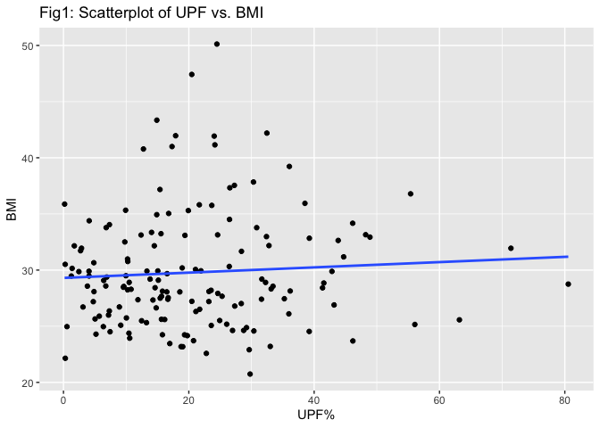

```r
ggplot(vars, aes(x = UPFpercentage_mean, y = BMI_cont)) +
  geom_point() +
  labs(title = "Fig1: Scatterplot of UPF vs. BMI", x = "UPF%", y = "BMI") +
  geom_smooth(method = lm, se = FALSE)
```

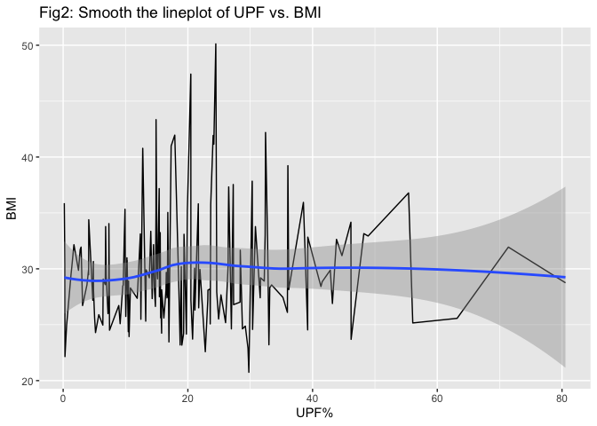

```r
ggplot(vars, aes(x = UPFpercentage_mean, y = BMI_cont)) +
  geom_line () +
  geom_smooth () +
  labs(title = "Fig2: Smooth the lineplot of UPF vs. BMI", x = "UPF%", y = "BMI")
```

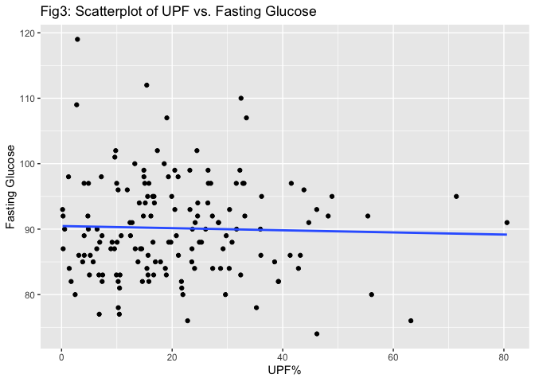

```r
ggplot(vars, aes(x = UPFpercentage_mean, y = Gluc_Fasting)) +
  geom_point() +
  labs(title = "Fig3: Scatterplot of UPF vs. Fasting Glucose", x = "UPF%", y = "Fasting Glucose") +
  geom_smooth(method = lm, se = FALSE)
```

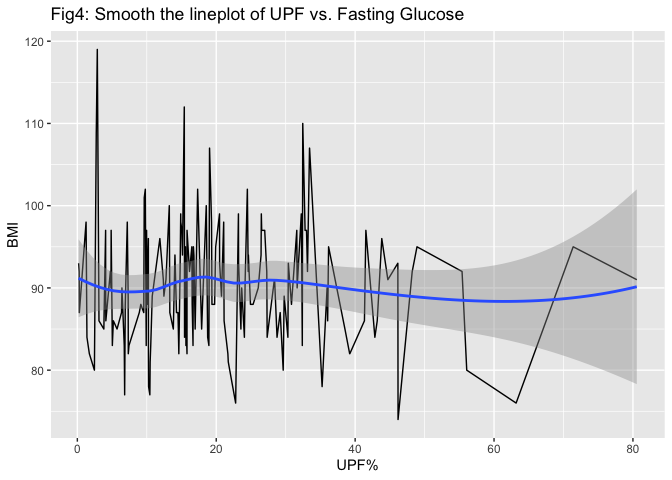

```r
ggplot(vars, aes(x = UPFpercentage_mean, y = Gluc_Fasting)) +
  geom_line () +
  geom_smooth () +
  labs(title = "Fig4: Smooth the lineplot of UPF vs. Fasting Glucose", x = "UPF%", y = "BMI")
```

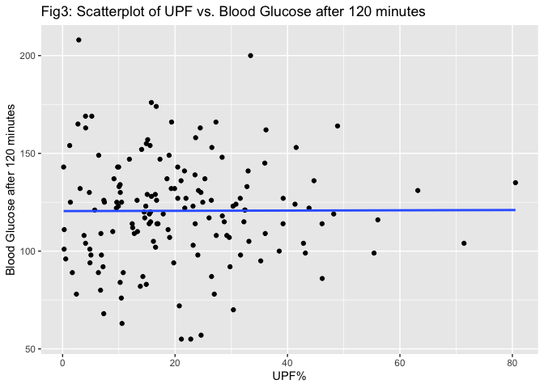

```r
ggplot(vars, aes(x = UPFpercentage_mean, y = Gluc_120min)) +
  geom_point() +
  labs(title = "Fig3: Scatterplot of UPF vs. Blood Glucose after 120 minutes", x = "UPF%", y = "Blood Glucose after 120 minutes") +
  geom_smooth(method = lm, se = FALSE)
```

Figure 4 fasting glucose by UPF quartiles shows that most subjects consumed 0-25% UPF and the second most subjects consumed 25-50% UPF. However, both UPF amounts consumption show no pattern for fasting flucose, which is also not normally distributed. This figure does not show any association between fasting glucose and UPF consumption.

Figure 5 Blood Glucose after 120 minutes shows that subjects consumed 0-25% and 25-50% UPF are almost normally distributed for their blood glucose level after 120 minutes. However, this figure also shows no association between blood glucose after 120 minutes and UPF consumption.

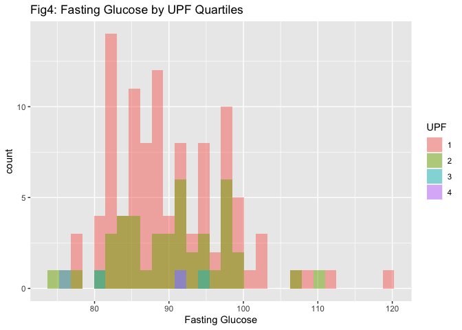

```r
vars %>%
  ggplot(aes(x = Gluc_Fasting, fill = UPF_quart)) +
  geom_histogram(position = "identity", alpha = 0.5) +
  labs(title = "Fig4: Fasting Glucose by UPF Quartiles", x = "Fasting Glucose", fill = "UPF")
```

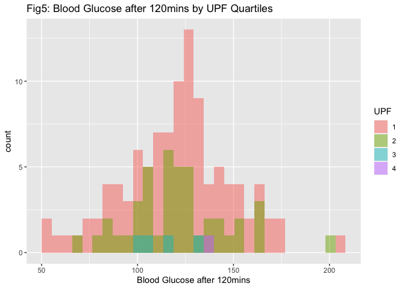

```r
vars %>%
  ggplot(aes(x = Gluc_120min, fill = UPF_quart)) +
  geom_histogram(position = "identity", alpha = 0.5) +
  labs(title = "Fig5: Blood Glucose after 120mins by UPF Quartiles", x = "Blood Glucose after 120mins", fill = "UPF")
```

Figure 6 BMI by UPF consumption shows that subjects who consumed 0-25% UPF had a pattern with right skewed, while subjects who comsumed greater than 25% UPF showed no specific pattern.

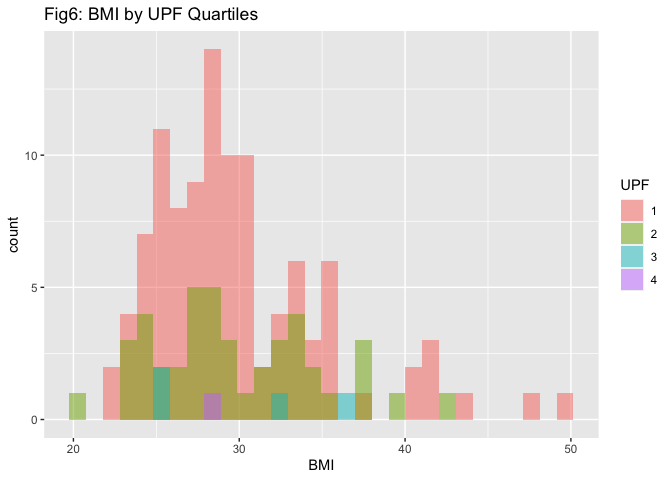

```r
vars %>%
  ggplot(aes(x = BMI_cont, fill = UPF_quart)) +
  geom_histogram(position = "identity", alpha = 0.5) +
  labs(title = "Fig6: BMI by UPF Quartiles", x = "BMI", fill = "UPF")
```

The barchart Figure 7 shows in another way that most subjects consumed low amount of UPFs were either overweight or obese.

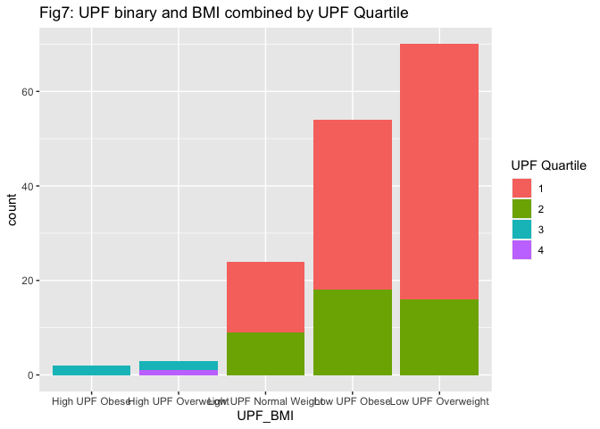

```r
vars %>%
  ggplot(aes(x = UPF_BMI, fill = UPF_quart)) +
  geom_bar() +
  labs(title = "Fig7: UPF binary and BMI combined by UPF Quartile", x = "UPF_BMI", fill = "UPF Quartile")
```

Figure 8 to Figure 11 are the statistical summary graphs of fasting glucose or blood glucose after 120 minutes by UPF quartiles of BMI.

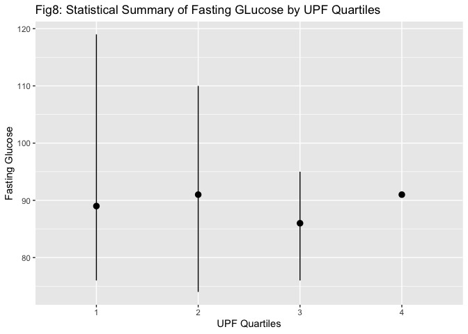

```r
vars %>%
  ggplot() +
  stat_summary(mapping = aes(x = UPF_quart, y = Gluc_Fasting),
               fun.min = min,
               fun.max = max,
               fun = median) +
  labs(title = "Fig8: Statistical Summary of Fasting GLucose by UPF Quartiles", x = "UPF Quartiles", y = "Fasting Glucose")
```

[figure not shown]

```r
vars %>%
  ggplot() +
  stat_summary(mapping = aes(x = UPF_quart, y = Gluc_120min),
               fun.min = min,
               fun.max = max,
               fun = median) +
  labs(title = "Fig9: Statistical Summary of Fasting GLucose by UPF Quartiles", x = "UPF Quartiles", y = "Glucose after 120mins")
```

[figure not shown]

```r
vars %>%
  ggplot() +
  stat_summary(mapping = aes(x = BMI_cat, y = Gluc_Fasting),
               fun.min = min,
               fun.max = max,
               fun = median) +
  labs(title = "Fig10: Statistical Summary of Fasting GLucose by UPF Quartiles", x = "BMI", y = "Fasting Glucose")
```

[figure not shown]

```r
vars %>%
  ggplot() +
  stat_summary(mapping = aes(x = BMI_cat, y = Gluc_120min),
               fun.min = min,
               fun.max = max,
               fun = median) +
  labs(title = "Fig11: Statistical Summary of Fasting Glucose by UPF Quartiles", x = "BMI", y = "Glucose after 120mins")
```

Conclusion: Based on the above data exploration and graphs, no clear pattern shows that UPF consumption is associated with obesity or T2DM. One reason can be the number of participants is limited.